# CMAverse Quickstart Guide

2024-02-16

We illustrate the general workflow of the `CMAverse` package by a quick example. The general workflow is:

1. Plot the DAG of causal relationships using `cmdag`.
2. Estimate causal effects and make inferences using `cmest`.
3. Conduct sensitivity analysis for unmeasured confounding and measurement error using `cmsens`.

Firstly, let’s load the package.

```r
library(CMAverse)
```

Next, we simulate some data and plot the DAG. The simulated dataset contains a binary exposure, a binary mediator, a continuous mediator, a continuous outcome and two baseline confounders.

```r
set.seed(1)
n <- 100
C1 <- rnorm(n, mean = 1, sd = 1)
C2 <- rbinom(n, 1, 0.6)
pa <- exp(0.2 - 0.5*C1 + 0.1*C2)/(1 + exp(0.2 - 0.5*C1 + 0.1*C2))
A <- rbinom(n, 1, pa)
pm <- exp(1 + 0.5*A - 1.5*C1 + 0.5*C2)/ (1 + exp(1 + 0.5*A - 1.5*C1 + 0.5*C2))
M1 <- rbinom(n, 1, pm)
M2 <- rnorm(n, 2 + 0.8*A - M1 + 0.5*C1 + 2*C2, 1)
Y <- rnorm(n, mean = 0.5 + 0.4*A + 0.5*M1 + 0.6*M2 + 0.3*A*M1 + 0.2*A*M2 - 0.3*C1 + 2*C2, sd = 1)
data <- data.frame(A, M1, M2, Y, C1, C2)
```

The DAG can be plotted using `cmdag`.

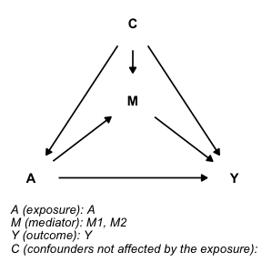

```r
cmdag(outcome = "Y", exposure = "A", mediator = c("M1", "M2"),
      basec = c("C1", "C2"), postc = NULL, node = FALSE, text_col = "black")
```

Then, we estimate causal effects using `cmest`. We use the regression-based approach for illustration. The reference values for the exposure are set to be 0 and 1. The reference values for the two mediators are set to be 1.

```r
est <- cmest(data = data, model = "rb", outcome = "Y", exposure = "A",
                mediator = c("M1", "M2"), basec = c("C1", "C2"), EMint = TRUE,
                mreg = list("logistic", "linear"), yreg = "linear",
                astar = 0, a = 1, mval = list(1, 1),
                estimation = "imputation", inference = "bootstrap", nboot = 20)
```

Summarize and plot the results:

```r
summary(est)
```

```
## Causal Mediation Analysis
##
## # Outcome regression:
##
## Call:
## glm(formula = Y ~ A + M1 + M2 + A * M1 + A * M2 + C1 + C2, family = gaussian(),
##     data = getCall(x$reg.output$yreg)$data, weights = getCall(x$reg.output$yreg)$weights)
##
## Deviance Residuals:
##      Min        1Q    Median        3Q       Max
## -2.47763  -0.59177   0.03214   0.66470   1.92837
##
## Coefficients:
##              Estimate Std. Error t value Pr(>|t|)
## (Intercept) -0.429317   0.446678  -0.961   0.3390
## A            1.305199   0.751816   1.736   0.0859 .
## M1           0.762169   0.310811   2.452   0.0161 *
## M2           0.691868   0.132038   5.240 1.01e-06 ***
## C1          -0.197350   0.136885  -1.442   0.1528
## C2           2.389790   0.355404   6.724 1.46e-09 ***
## A:M1         0.127853   0.466496   0.274   0.7846
## A:M2        -0.001608   0.151163  -0.011   0.9915
## ---
## Signif. codes:  0 '***' 0.001 '**' 0.01 '*' 0.05 '.' 0.1 ' ' 1
##
## (Dispersion parameter for gaussian family taken to be 1.100923)
##
##     Null deviance: 571.51  on 99  degrees of freedom
## Residual deviance: 101.28  on 92  degrees of freedom
## AIC: 303.06
##
## Number of Fisher Scoring iterations: 2
##
##
## # Mediator regressions:
##
## Call:
## glm(formula = M1 ~ A + C1 + C2, family = binomial(), data = getCall(x$reg.output$mreg[[1L]])$data,
##     weights = getCall(x$reg.output$mreg[[1L]])$weights)
##
```

[output cut: 73 more lines]

```
## (cde: controlled direct effect; pnde: pure natural direct effect; tnde: total natural direct effect; pnie: pure natural indirect effect; tnie: total natural indirect effect; te: total effect; intref: reference interaction; intmed: mediated interaction; cde(prop): proportion cde; intref(prop): pro…
##
## Relevant variable values:
## $a
## [1] 1
##
## $astar
## [1] 0
##
## $mval
## $mval[[1]]
## [1] 1
##
## $mval[[2]]
## [1] 1
```

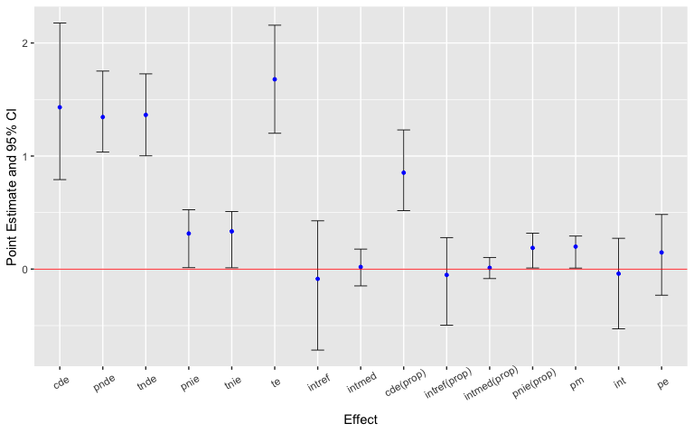

```r
ggcmest(est) +
  ggplot2::theme(axis.text.x = ggplot2::element_text(angle = 30, vjust = 0.8))
```

Lastly, we conduct sensitivity analysis for the results. Sensitivity analysis for unmeasured confounding:

```r
cmsens(object = est, sens = "uc")
```

```
## Sensitivity Analysis For Unmeasured Confounding
##
## Evalues on the risk or rate ratio scale:
##         estRR   lowerRR  upperRR Evalue.estRR Evalue.lowerRR Evalue.upperRR
## cde  1.719704 1.2724617 2.324143     2.832214       1.861272             NA
## pnde 1.664318 1.4239257 1.945293     2.715810       2.200868             NA
## tnde 1.676154 1.4211994 1.976847     2.740738       2.194897             NA
## pnie 1.126739 0.9896507 1.282818     1.504631       1.000000             NA
## tnie 1.134753 1.0152410 1.268333     1.525791       1.139632             NA
## te   1.888589 1.5321886 2.327891     3.184035       2.435191             NA
```

Assume that $C_1$ was measured with error. Sensitivity analysis for measurement error using regression calibration with a set of assumed error standard deviations 0.1, 0.2 and 0.3:

```r
me1 <- cmsens(object = est, sens = "me", MEmethod = "rc",
              MEvariable = "C1", MEvartype = "con", MEerror = c(0.1, 0.2, 0.3))
```

Summarize and plot the results:

```r
summary(me1)
```

```
## Sensitivity Analysis For Measurement Error
##
## The variable measured with error: C1
## Type of the variable measured with error: continuous
##
## # Measurement error 1:
## [1] 0.1
##
## ## Error-corrected regressions for measurement error 1:
##
## ### Outcome regression:
## Call:
## rcreg(reg = getCall(x$sens[[1L]]$reg.output$yreg)$reg, formula = Y ~
##     A + M1 + M2 + A * M1 + A * M2 + C1 + C2, data = getCall(x$sens[[1L]]$reg.output$yreg)$data,
##     MEvariable = "C1", MEerror = 0.1, variance = TRUE, nboot = 400,
##     weights = getCall(x$sens[[1L]]$reg.output$yreg)$weights)
##
## Naive coefficient estimates:
##  (Intercept)            A           M1           M2           C1           C2
## -0.429317055  1.305199111  0.762169424  0.691868043 -0.197349688  2.389790272
##         A:M1         A:M2
##  0.127853354 -0.001607689
##
## Naive var-cov estimates:
##             (Intercept)            A           M1           M2           C1
## (Intercept)  0.19952129 -0.186177297 -0.071800151 -0.042143887 -0.012473494
## A           -0.18617730  0.565227608  0.061763824  0.035566831  0.008550886
## M1          -0.07180015  0.061763824  0.096603550  0.011127995  0.008367323
## M2          -0.04214389  0.035566831  0.011127995  0.017433949 -0.005541985
## C1          -0.01247349  0.008550886  0.008367323 -0.005541985  0.018737581
## C2           0.03202116 -0.002076496 -0.025485517 -0.031937394  0.011413789
## A:M1         0.05250394 -0.194186113 -0.081844376  0.001218548 -0.006350845
## A:M2         0.03868322 -0.102112096 -0.008061219 -0.010381316 -0.000334026
##                       C2         A:M1         A:M2
## (Intercept)  0.032021156  0.052503937  0.038683218
## A           -0.002076496 -0.194186113 -0.102112096
## M1          -0.025485517 -0.081844376 -0.008061219
## M2          -0.031937394  0.001218548 -0.010381316
## C1           0.011413789 -0.006350845 -0.000334026
## C2           0.126311866 -0.027375016  0.006147880
```

[output cut: 379 more lines]

```
## (cde: controlled direct effect; pnde: pure natural direct effect; tnde: total natural direct effect; pnie: pure natural indirect effect; tnie: total natural indirect effect; te: total effect; intref: reference interaction; intmed: mediated interaction; cde(prop): proportion cde; intref(prop): pro…
##
## Relevant variable values:
## $a
## [1] 1
##
## $astar
## [1] 0
##
## $mval
## $mval[[1]]
## [1] 1
##
## $mval[[2]]
## [1] 1
```

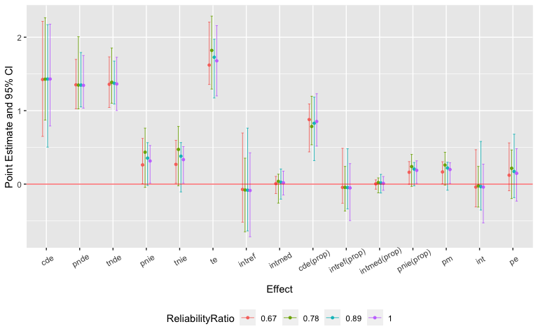

```r
ggcmsens(me1) +
  ggplot2::theme(axis.text.x = ggplot2::element_text(angle = 30, vjust = 0.8))
```

Then, assume that the exposure was measured with error. Sensitivity analysis for measurement error using SIMEX with two assumed misclassification matrices:

```r
me2 <- cmsens(object = est, sens = "me", MEmethod = "simex", MEvariable = "A",
              MEvartype = "cat", B = 5,
              MEerror = list(matrix(c(0.95, 0.05, 0.05, 0.95), nrow = 2),
                             matrix(c(0.9, 0.1, 0.1, 0.9), nrow = 2)))
```

Summarize and plot the results:

```r
summary(me2)
```

```
## Sensitivity Analysis For Measurement Error
##
## The variable measured with error: A
## Type of the variable measured with error: categorical
##
## # Measurement error 1:
##      [,1] [,2]
## [1,] 0.95 0.05
## [2,] 0.05 0.95
##
## ## Error-corrected regressions for measurement error 1:
##
## ### Outcome regression:
## Call:
## simexreg(reg = getCall(x$sens[[1L]]$reg.output$yreg)$reg, formula = Y ~
##     A + M1 + M2 + A * M1 + A * M2 + C1 + C2, data = getCall(x$sens[[1L]]$reg.output$yreg)$data,
##     MEvariable = "A", MEvartype = "categorical", MEerror = c(0.95,
##     0.05, 0.05, 0.95), variance = TRUE, lambda = c(0.5, 1, 1.5,
##     2), B = 5, weights = getCall(x$sens[[1L]]$reg.output$yreg)$weights)
##
## Naive coefficient estimates:
##  (Intercept)            A           M1           M2           C1           C2
## -0.429317055  1.305199111  0.762169424  0.691868043 -0.197349688  2.389790272
##         A:M1         A:M2
##  0.127853354 -0.001607689
##
## Naive var-cov estimates:
##             (Intercept)            A           M1           M2           C1
## (Intercept)  0.19952129 -0.186177297 -0.071800151 -0.042143887 -0.012473494
## A           -0.18617730  0.565227608  0.061763824  0.035566831  0.008550886
## M1          -0.07180015  0.061763824  0.096603550  0.011127995  0.008367323
## M2          -0.04214389  0.035566831  0.011127995  0.017433949 -0.005541985
## C1          -0.01247349  0.008550886  0.008367323 -0.005541985  0.018737581
## C2           0.03202116 -0.002076496 -0.025485517 -0.031937394  0.011413789
## A:M1         0.05250394 -0.194186113 -0.081844376  0.001218548 -0.006350845
## A:M2         0.03868322 -0.102112096 -0.008061219 -0.010381316 -0.000334026
##                       C2         A:M1         A:M2
## (Intercept)  0.032021156  0.052503937  0.038683218
## A           -0.002076496 -0.194186113 -0.102112096
## M1          -0.025485517 -0.081844376 -0.008061219
```

[output cut: 269 more lines]

```
## (cde: controlled direct effect; pnde: pure natural direct effect; tnde: total natural direct effect; pnie: pure natural indirect effect; tnie: total natural indirect effect; te: total effect; intref: reference interaction; intmed: mediated interaction; cde(prop): proportion cde; intref(prop): pro…
##
## Relevant variable values:
## $a
## [1] 1
##
## $astar
## [1] 0
##
## $mval
## $mval[[1]]
## [1] 1
##
## $mval[[2]]
## [1] 1
```

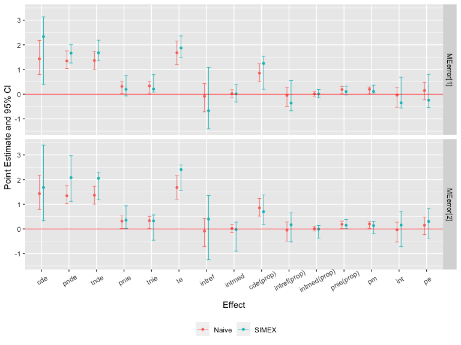

```r
ggcmsens(me2) +
  ggplot2::theme(axis.text.x = ggplot2::element_text(angle = 30, vjust = 0.8))
```